# Objective:

The customer's dataset for treadmill product(s) of Cardio Good Fitness retail store should be explored and basic observations about the data to be extracted. Preliminary Data Analysis needs to be carried out.

Following are the main tasks in the analysis :

1. Come up with a customer profile (characteristics of a customer) of the different products
2. Perform uni-variate and multi-variate analyses
3. Generate a set of insights and recommendations that will help the company in targeting new customers

# Dataset:

- Product - the model no. of the treadmill
- Age - in no of years, of the customer
- Gender - of the customer
- Education - in no. of years, of the customer
- Marital Status - of the customer
- Usage - Avg. # times the customer wants to use the treadmill every week
- Fitness - Self rated fitness score of the customer (5 - very fit, 1 - very unfit)
- Income - of the customer
- Miles- expected to run

# Key questions to be answered:

- What is the age group of customers for each product?
- Is there a gender inclination in the customer base of each product? Is a particular product used more by men or women?
- Is there an income category of customers for each product?
- What is the education profile of customers for each product?
- For each product is the customer base falling into the married category or the unmarried catgeory?
- What is the usage for each product?
- What is the fitness score of customers for each product?
- What is the avergae miles expected to run on each type of treamill to achieve the fitness levels?

### Import the necessary packages - pandas, numpy, seaborn, matplotlib.pyplot

```python
import pandas as pd
import numpy as np
import seaborn as sns
import matplotlib.pyplot as plt
%matplotlib inline
import warnings
sns.set(color_codes=True)
```

### Read in the dataset

```python
cardiodata = pd.read_csv("D:\course\CARDIOGOODFITNESS.csv")
```

### Shape of the dataset

```python
cardiodata.shape
```

```
(180, 9)
```

Observations: There are 180 observations of 9 columns

### Check the datatype of the variables

```python
cardiodata.dtypes
```

```
Product          object
Age               int64
Gender           object
Education         int64
MaritalStatus    object
Usage             int64
Fitness           int64
Income            int64
Miles             int64
dtype: object
```

Observations:

1. Product, Gender, Marital Status are of object data type
2. Age, Education, Usage, Fitness, Income, Miles are of integer type

### Check the missing values

```python
cardiodata.isnull().sum()
```

```
Product          0
Age              0
Gender           0
Education        0
MaritalStatus    0
Usage            0
Fitness          0
Income           0
Miles            0
dtype: int64
```

Observations:

- There are no missing values in any of the 9 columns in the cardio dataset

### Columns in the Dataset. Dimensions of the data

```python
cardiodata.columns
```

```
Index(['Product', 'Age', 'Gender', 'Education', 'MaritalStatus', 'Usage',
       'Fitness', 'Income', 'Miles'],
      dtype='object')
```

Observations:

- The main columns of the data are : 'Product', 'Age', 'Gender', 'Education', 'MaritalStatus', 'Usage','Fitness', 'Income', 'Miles'

### Analysis of the quantitative variables in the cardio dataset

```python
cardiodata.describe().T
```

|  | count | mean | std | min | 25% | 50% | 75% | max |
| --- | --- | --- | --- | --- | --- | --- | --- | --- |
| Age | 180.0 | 28.788889 | 6.943498 | 18.0 | 24.00 | 26.0 | 33.00 | 50.0 |
| Education | 180.0 | 15.572222 | 1.617055 | 12.0 | 14.00 | 16.0 | 16.00 | 21.0 |
| Usage | 180.0 | 3.455556 | 1.084797 | 2.0 | 3.00 | 3.0 | 4.00 | 7.0 |
| Fitness | 180.0 | 3.311111 | 0.958869 | 1.0 | 3.00 | 3.0 | 4.00 | 5.0 |
| Income | 180.0 | 53719.577778 | 16506.684226 | 29562.0 | 44058.75 | 50596.5 | 58668.00 | 104581.0 |
| Miles | 180.0 | 103.194444 | 51.863605 | 21.0 | 66.00 | 94.0 | 114.75 | 360.0 |

Observations:

```python
cardiodata.groupby(['Product']).describe().T
```

|  | Product | TM195 | TM498 | TM798 |
| --- | --- | --- | --- | --- |
| Age | count | 80.000000 | 60.000000 | 40.000000 |
|  | mean | 28.550000 | 28.900000 | 29.100000 |
|  | std | 7.221452 | 6.645248 | 6.971738 |
|  | min | 18.000000 | 19.000000 | 22.000000 |
|  | 25% | 23.000000 | 24.000000 | 24.750000 |
|  | 50% | 26.000000 | 26.000000 | 27.000000 |
|  | 75% | 33.000000 | 33.250000 | 30.250000 |
|  | max | 50.000000 | 48.000000 | 48.000000 |
| Education | count | 80.000000 | 60.000000 | 40.000000 |
|  | mean | 15.037500 | 15.116667 | 17.325000 |
|  | std | 1.216383 | 1.222552 | 1.639066 |
|  | min | 12.000000 | 12.000000 | 14.000000 |
|  | 25% | 14.000000 | 14.000000 | 16.000000 |
|  | 50% | 16.000000 | 16.000000 | 18.000000 |
|  | 75% | 16.000000 | 16.000000 | 18.000000 |
|  | max | 18.000000 | 18.000000 | 21.000000 |
| Usage | count | 80.000000 | 60.000000 | 40.000000 |
|  | mean | 3.087500 | 3.066667 | 4.775000 |
|  | std | 0.782624 | 0.799717 | 0.946993 |
|  | min | 2.000000 | 2.000000 | 3.000000 |
|  | 25% | 3.000000 | 3.000000 | 4.000000 |
|  | 50% | 3.000000 | 3.000000 | 5.000000 |
|  | 75% | 4.000000 | 3.250000 | 5.000000 |
|  | max | 5.000000 | 5.000000 | 7.000000 |
| Fitness | count | 80.000000 | 60.000000 | 40.000000 |
|  | mean | 2.962500 | 2.900000 | 4.625000 |
|  | std | 0.664540 | 0.629770 | 0.667467 |
|  | min | 1.000000 | 1.000000 | 3.000000 |
|  | 25% | 3.000000 | 3.000000 | 4.000000 |
|  | 50% | 3.000000 | 3.000000 | 5.000000 |
|  | 75% | 3.000000 | 3.000000 | 5.000000 |
|  | max | 5.000000 | 4.000000 | 5.000000 |
| Income | count | 80.000000 | 60.000000 | 40.000000 |
|  | mean | 46418.025000 | 48973.650000 | 75441.575000 |
|  | std | 9075.783190 | 8653.989388 | 18505.836720 |
|  | min | 29562.000000 | 31836.000000 | 48556.000000 |
|  | 25% | 38658.000000 | 44911.500000 | 58204.750000 |
|  | 50% | 46617.000000 | 49459.500000 | 76568.500000 |
|  | 75% | 53439.000000 | 53439.000000 | 90886.000000 |
|  | max | 68220.000000 | 67083.000000 | 104581.000000 |
| Miles | count | 80.000000 | 60.000000 | 40.000000 |
|  | mean | 82.787500 | 87.933333 | 166.900000 |
|  | std | 28.874102 | 33.263135 | 60.066544 |
|  | min | 38.000000 | 21.000000 | 80.000000 |
|  | 25% | 66.000000 | 64.000000 | 120.000000 |
|  | 50% | 85.000000 | 85.000000 | 160.000000 |
|  | 75% | 94.000000 | 106.000000 | 200.000000 |
|  | max | 188.000000 | 212.000000 | 360.000000 |

Observations:

### Univariate analysis for numerical variables with histograms

#### Univariate analysis for age

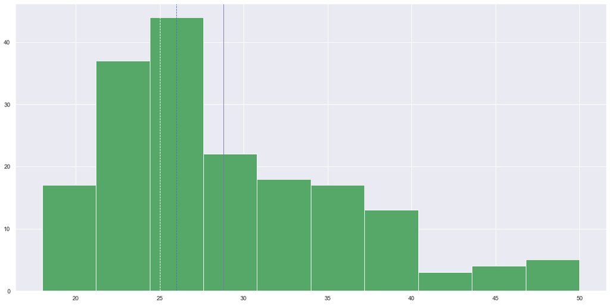

```python
age = cardiodata['Age']
plt.figure(figsize=(20,10))
plt.hist(age, color='g')
plt.axvline(age.mean(), color='m', linewidth=1)
plt.axvline(age.median(), color='b', linestyle='dashed', linewidth=1)
plt.axvline(age.mode()[0], color='w', linestyle='dashed', linewidth=1)
```

Observations:

#### Distribution plot for Age bringing out the same observations as above

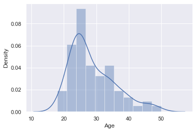

```python
sns.distplot(age)
```

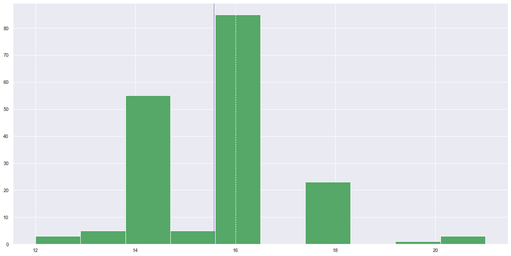

```python
education = cardiodata['Education']
plt.figure(figsize=(20,10))
plt.hist(education, color='g')
plt.axvline(education.mean(), color='m', linewidth=1)
plt.axvline(education.median(), color='b', linestyle='dashed', linewidth=1)
plt.axvline(education.mode()[0], color='w', linestyle='dashed', linewidth=1)
```

Observations:

- In this Education histogram the fifth bin has the most observations. Maximum number of the customers of these products have education between 15.5 - 16.5 years
- A bulk of observations lie in the first 5 bins. The rest of the 5 bins contain few observations. Most of the users have equal to or less then 16.5 years of education. Relatively few customers above 16.5 years of education.
- Very few customers have more than 20 years of education

#### Distribution plot for Education bringing out the same observations as above

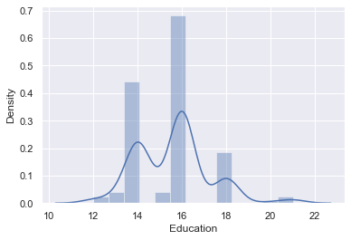

```python
sns.distplot(education)
```

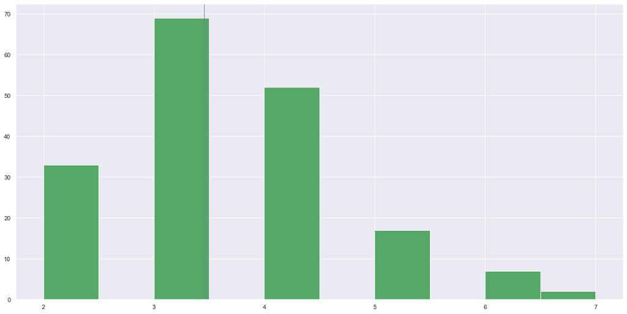

```python
usage = cardiodata['Usage']
plt.figure(figsize=(20,10))
plt.hist(usage, color='g')
plt.axvline(usage.mean(), color='m', linewidth=1)
plt.axvline(usage.median(), color='b', linestyle='dashed', linewidth=1)
plt.axvline(usage.mode()[0], color='w', linestyle='dashed', linewidth=1)
```

Observations:

#### Distribution plot for Usage bringing out the same observations as above

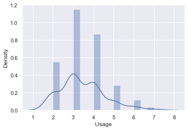

```python
sns.distplot(usage)
```

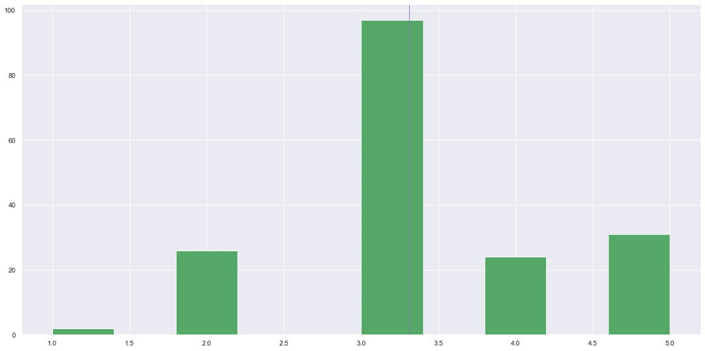

```python
fitness = cardiodata['Fitness']
plt.figure(figsize=(20,10))
plt.hist(fitness, color='g')
plt.axvline(fitness.mean(), color='m', linewidth=1)
plt.axvline(fitness.median(), color='b', linestyle='dashed', linewidth=1)
plt.axvline(fitness.mode()[0], color='w', linestyle='dashed', linewidth=1)
```

Observations:

#### Distribution plot for fitness bringing out the same observations as above

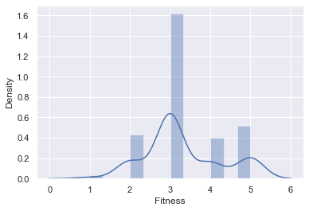

```python
sns.distplot(fitness)
```

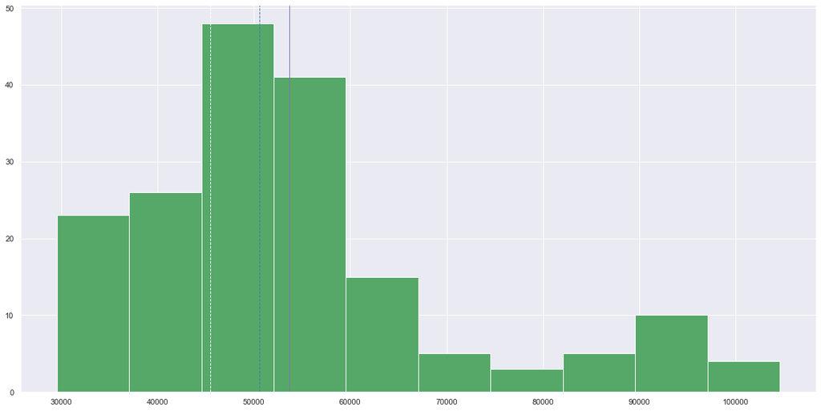

```python
income = cardiodata['Income']
plt.figure(figsize=(20,10))
plt.hist(income, color='g')
plt.axvline(income.mean(), color='m', linewidth=1)
plt.axvline(income.median(), color='b', linestyle='dashed', linewidth=1)
plt.axvline(income.mode()[0], color='w', linestyle='dashed', linewidth=1)
```

Observations:

- In this income histogram the third bin has the most observations. Maximum number of the customers of these products have an income between 44000-52000. Second highest number of customers fall in the income range of 52000-60000
- A bulk of observations lie in the first 4 classes. The rest of the 6 classes contain few observations.
- 50% of the customers have less then 52000 in annual income.
- Mean is represented by magenta line, mode by white line and median by blue line.
- Mean and median are close to each and other and mean is greater than both. This is positively skewed.
- Very few customers have an income above 70000. Most of the customers have an income till 60000.

#### Distribution plot for income bringing out the same observations as above

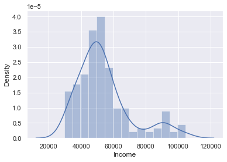

```python
sns.distplot(income);
```

#### Univariate analysis for miles

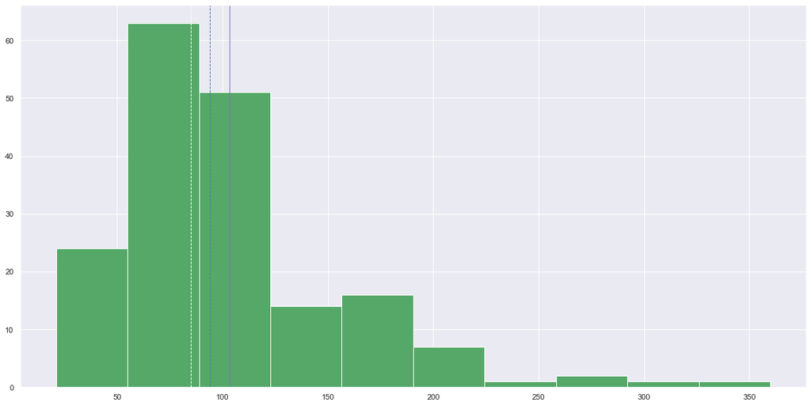

```python
miles = cardiodata['Miles']
plt.figure(figsize=(20,10))
plt.hist(miles, color='g')
plt.axvline(miles.mean(), color='m', linewidth=1)
plt.axvline(miles.median(), color='b', linestyle='dashed', linewidth=1)
plt.axvline(miles.mode()[0], color='w', linestyle='dashed', linewidth=1)
```

Observations:

#### Distribution plot for miles bringing out the same observations as above¶

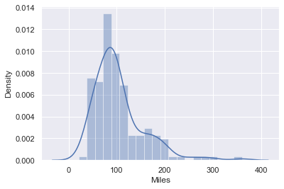

```python
sns.distplot(miles);
```

#### Relationship between numerical variables using pair plots and correlation plots

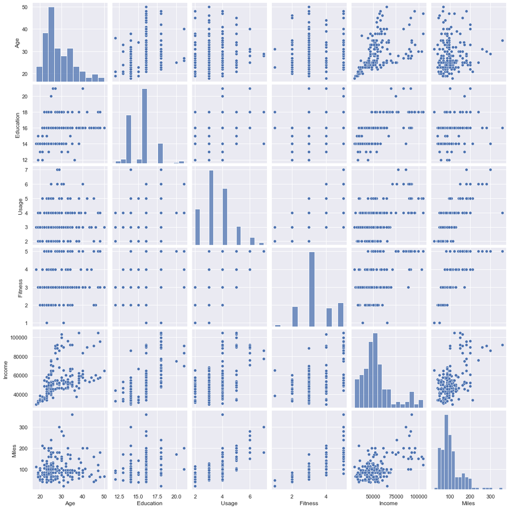

```python
sns.pairplot(cardiodata);
```

```python
correlation = cardiodata.corr() # creating a 2-D Matrix with correlation plots
correlation
```

|  | Age | Education | Usage | Fitness | Income | Miles |
| --- | --- | --- | --- | --- | --- | --- |
| Age | 1.000000 | 0.280496 | 0.015064 | 0.061105 | 0.513414 | 0.036618 |
| Education | 0.280496 | 1.000000 | 0.395155 | 0.410581 | 0.625827 | 0.307284 |
| Usage | 0.015064 | 0.395155 | 1.000000 | 0.668606 | 0.519537 | 0.759130 |
| Fitness | 0.061105 | 0.410581 | 0.668606 | 1.000000 | 0.535005 | 0.785702 |
| Income | 0.513414 | 0.625827 | 0.519537 | 0.535005 | 1.000000 | 0.543473 |
| Miles | 0.036618 | 0.307284 | 0.759130 | 0.785702 | 0.543473 | 1.000000 |

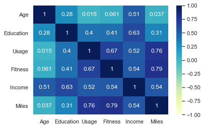

```python
sns.heatmap(correlation, annot=True, cmap='YlGnBu', vmin=-1, vmax=1);
```

Observations:

- Age has positive correlation with income, usage with income, fitness with income, expected miles to run with income, income and usage.
- There is a high correlation between education and income, fitness and usage, usage and expected miles to run, fitness and miles expected to run.
- Age does not have a high correlation with any of the dimensions apart from income.
- Education does not have a high correlation with any of the dimensions apart from income.
- Income has a high correlation with all the rest of the attributes captured.

## Bivariate analysis based on main categorical feature Product

### Basic countplot to check which treadmill product is widely used

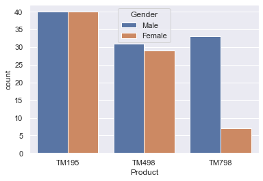

```python
sns.countplot(data=cardiodata, x='Product',hue="Gender");
```

Observations:-

- Model TM195 is used more in the dataset with 80/180 using it.
- Model TM798 is least used in the dataset with 40/180 using it.
- Model TM798 is rarely used by women.
- Model TM195 is used equally by men and women.

### Catplot to check which treadmill product usage by gender and marital status

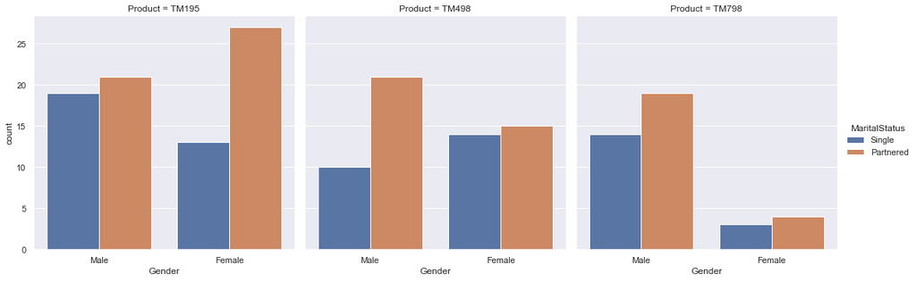

```python
sns.catplot(x="Gender",hue="MaritalStatus",col="Product",data=cardiodata, kind="count");
```

Observations:-

- Model TM195 is used more by married women rather than single women.In fact married women in the single largest category of TM195 users
- Model TM498 is least used by single men.
- Model TM798 is rarely used by women and in that by single women

##### * For TM195 married women are the single largest segment of customers

##### * For TM195 is used by more married people as compared to single individuals in both men and women. For women the married women using TM 195 is double than single women.

##### * For TM798 market segment consists mainly of men

##### * For TM498 market segment for married men is double the single men.

##### * Overall married people use all three products more than single people.

### Catplot to check which treadmill product usage by gender , age and marital status

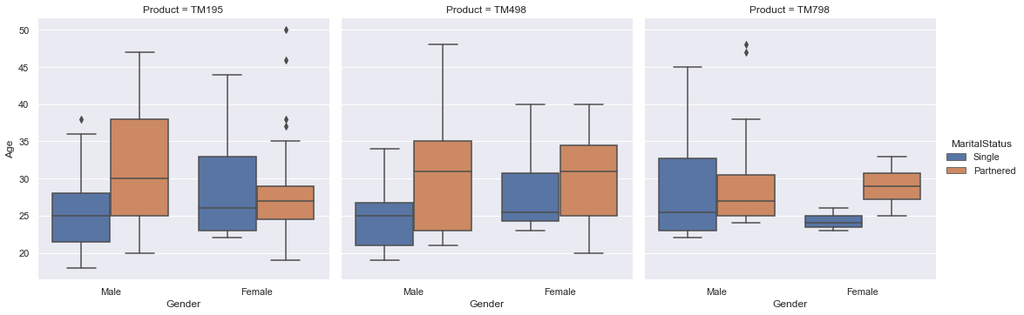

```python
sns.catplot(x="Gender",y="Age", hue="MaritalStatus",col="Product",data=cardiodata, kind="box");
```

Observations:-

##### * For TM195 even if married women are the single largest segment of customers 50% of them are between 25-30 years¶

##### * For TM195 age range of single women is broader than married women.

##### * For TM498 market segment age range for married men is broader than single men

##### * For TM798 market segment for single men is broader than married men

### Catplot to check which treadmill product usage by gender , Education and marital status

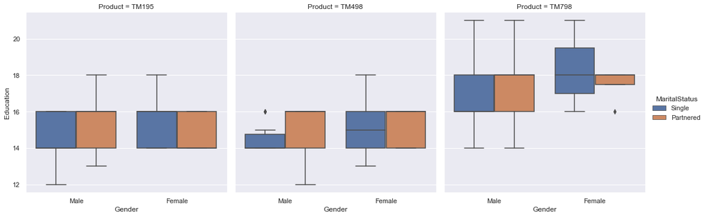

```python
sns.catplot(x="Gender",y="Education", hue="MaritalStatus",col="Product",data=cardiodata, kind="box");
```

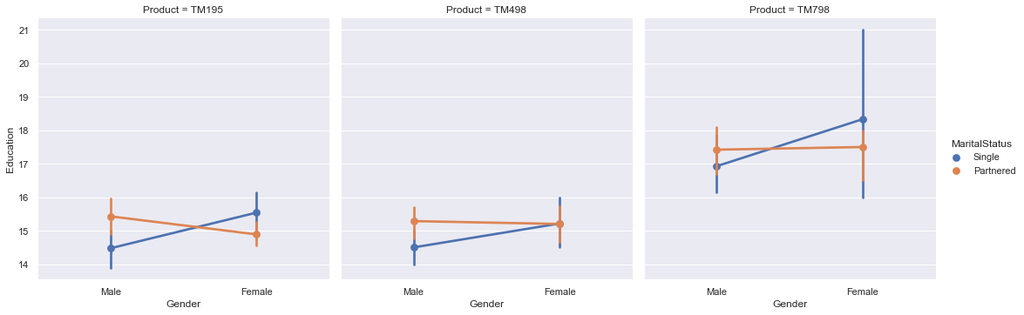

```python
sns.catplot(x="Gender",y="Education", hue="MaritalStatus",col="Product",data=cardiodata, kind="point");
```

Observations:-

#### TM 798 is used by more educated people both male and female and married and single.

### Catplot to check which treadmill product usage by gender , usage and marital status

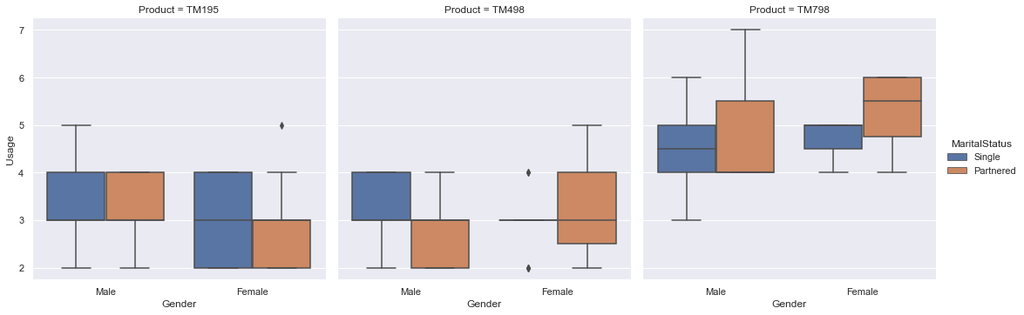

```python
sns.catplot(x="Gender",y="Usage", hue="MaritalStatus",col="Product",data=cardiodata, kind="box");
```

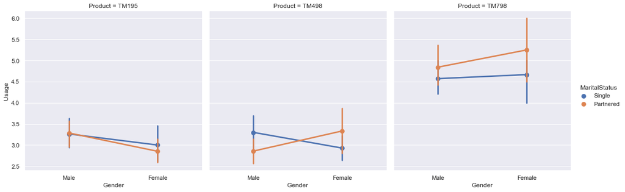

```python
sns.catplot(x="Gender",y="Usage", hue="MaritalStatus",col="Product",data=cardiodata, kind="point");
```

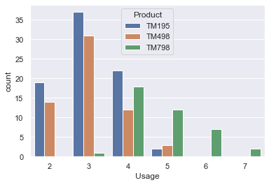

```python
sns.countplot(data=cardiodata, x='Usage',hue="Product");
```

Observations

#### TM 798 average usage is higher than 4.5 times per week and is also higher than other two products for all categories of men and women

#### TM 195 75% of married men have an usage of 3-4 hours and 75% of married women have an usage between 2-3 hours. 25% of single men have an usage 4-5 hours. 50% of single women have an usage between 2-3 hours and 50% between 3-4 hours.

#### TM 498 75% of married men have an usage of 2-3 hours where as 75% of single men have an usage betwwen 3-4 hours. All single women apart from 2 outliers have usage of 3 hours. 50% of married women have an usage between 2.5 - 4 hours.

### Catplot to check which treadmill product usage by gender , fitness and marital status

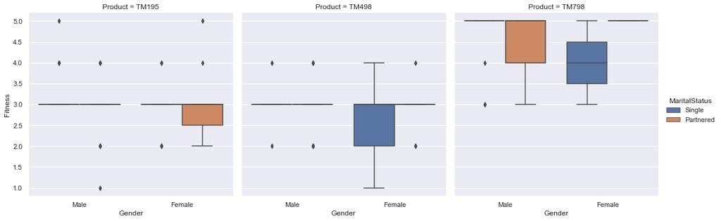

```python
sns.catplot(x="Gender",y="Fitness", hue="MaritalStatus",col="Product",data=cardiodata, kind="box");
```

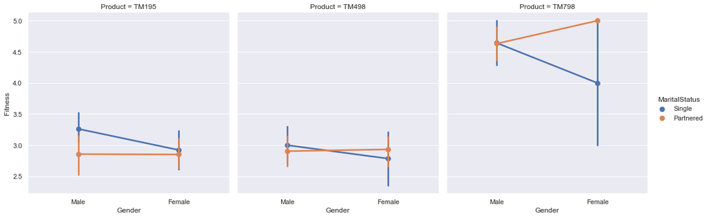

```python
sns.catplot(x="Gender",y="Fitness", hue="MaritalStatus",col="Product",data=cardiodata, kind="point");
```

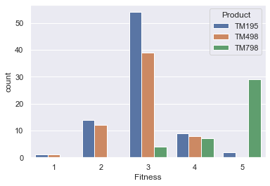

```python
sns.countplot(data=cardiodata, x='Fitness',hue="Product");
```

Observations

- TM195 Almost all the men have a fitness ranking of 3 apart from a few outliers.
- TM195 50% of the married women are in the range of 2.5 and 3 fitness level. All single women have the fitness level of 3.
- TM498 Almost all men have a fitness level of 3 apart from few outliers.
- TM498 50% of single women have a fitness level between 2 - 3. Almost all married women have a fitness level of 3 apart from some outliers
- TM798 almost all single men are extremely fit with fitness rating of 5. Only 2 outliers.50% of married men have fitness level in range of 4-5.
- TM798 All married women using the product have a fitness level of 5.

##### For TM798 the average fitness level for all categories is 4 or above. It is used by the most fit people.

##### For TM195 the fitness level is 3 for all categories of men and 3 for all single women apart from some outliers

##### For TM498 the fitness level is 3 for all categories of men and 3 for all married women apart from some outliers

### Catplot to check which treadmill product usage by gender , income and marital status

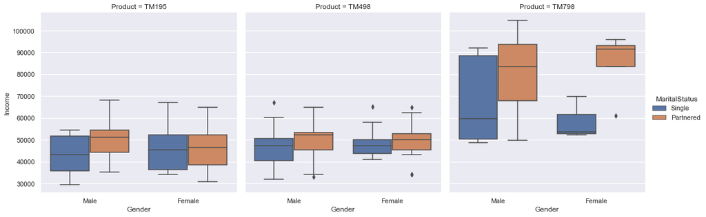

```python
sns.catplot(x="Gender",y="Income", hue="MaritalStatus",col="Product",data=cardiodata, kind="box");
```

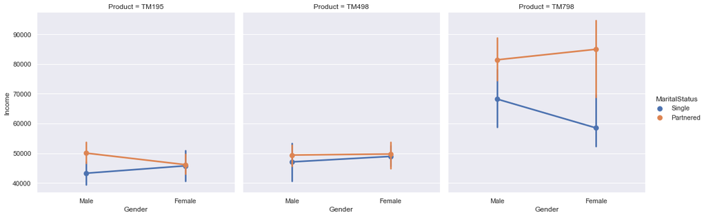

```python
sns.catplot(x="Gender",y="Income", hue="MaritalStatus",col="Product",data=cardiodata, kind="point");
```

Observations

##### For TM798 the average income is higher than 55000. It is used by people with more annual income.

##### For TM195 the customers have the lowest average income between 42000-50000 as compared to other products. It is used by people with lower annual income.

##### For TM498 the average income is close to 50000.

### Catplot to check which treadmill product usage by gender , miles expected to run and marital status

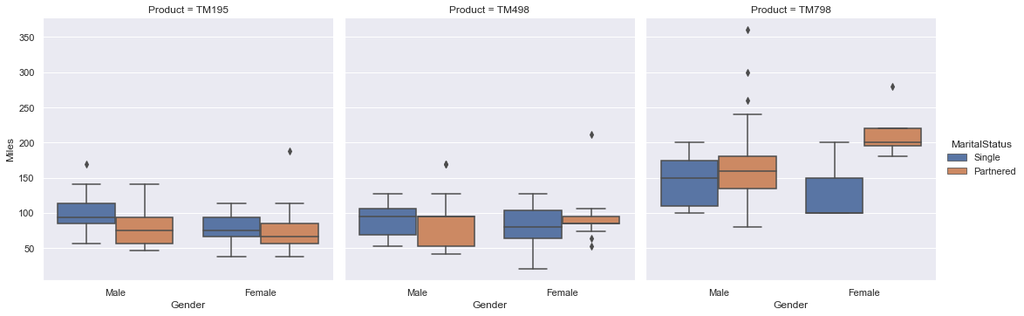

```python
sns.catplot(x="Gender",y="Miles", hue="MaritalStatus",col="Product",data=cardiodata, kind="box");
```

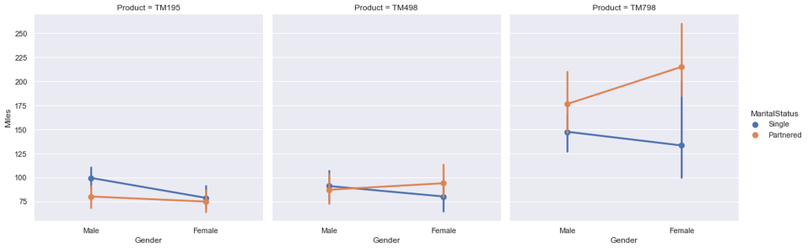

```python
sns.catplot(x="Gender",y="Miles", hue="MaritalStatus",col="Product",data=cardiodata, kind="point");
```

Observations

- TM195 75% Single men are expected to run 120 miles. 75% of Married men and 75% of all women are expected to use under 100 miles
- TM498 The range for married women is significantly lower as compared to rest of the three categories.
- TM798 All categories of users are expected to run for more miles than other two products.

### Conclusions:

##### TM195 :

- TM195 is the most used product more than the other two.
- Model TM195 is used equally by men and women.
- For TM195 married women are the single largest segment of customers.
- TM195 is used by more married people as compared to single individuals in both men and women. For women the married women using TM 195 is double than single women.
- For TM195 even if married women are the single largest segment of customers 50% of them are between 25-30 years
- For TM195 average education is between 14-16 years.
- TM 195 75% of married men have an usage of 3-4 hours and 75% of married women have an usage between 2-3 hours. 25% of single men have an usage 4-5 hours. 50% of single women have an usage between 2-3 hours and 50% between 3-4 hours.
- For TM195 the fitness level is 3 for all categories of men and 3 for all single women apart from some outliers.
- For TM195 the customers have the lowest average income between 42000-50000 as compared to other products. It is used by people with lower annual income.
- For TM195 the average miles expected to run is less 100 or less for both categories of men.

##### TM 498 :

- Model TM498 is is used more by married men than single men. The number of married men using this product is double the single men.
- TM 498 75% of married men have an usage of 2-3 hours where as 75% of single men have an usage betwwen 3-4 hours. All single women apart from 2 outliers have usage of 3 hours. 50% of married women have an usage between 2.5 - 4 hours.
- For TM498 the average income is close to 50000.
- For TM498 the fitness level is 3 for all categories of men and 3 for all married women apart from some outliers.

##### TM 798 :

- For TM798 market segment consists mainly of men. Few women use this product.
- Model TM798 is least used amongst the 3 treadmills.
- TM 798 is used by more educated people both men and women and married and single.
- TM 798 average usage is higher than 4.5 times per week and is also higher than other two products for all categories of men and women
- For TM798 the average income is higher than 55000. It is used by people with more annual income.
- For TM798 the average miles expected to run is more than 125 and is higher than other two products.
- For TM798 the average fitness level for all categories is 4 or above. It is used by the most fit people.